# CNN Model to predict seamounts

# Model Definition and Evaluation

1. Model Selection
2. Feature Engineering
3. Hyperparameter Tuning
4. Implementation
5. Evaluation Metrics
6. Comparative Analysis

```python
# Import necessary libraries
import os
import cv2
from collections import Counter
from datetime import datetime
import tensorflow as tf
from tensorflow.keras.models import Sequential
from tensorflow.keras.layers import Input, Conv2D, MaxPooling2D, Flatten, Dense, Dropout
from tensorflow.keras.preprocessing.image import ImageDataGenerator
from sklearn.metrics import classification_report
from sklearn.model_selection import train_test_split
from tensorflow.keras.models import load_model
import numpy as np
import matplotlib.pyplot as plt

# Parameters
image_folder = "./main_input_data/data_241208"  # Root directory of the dataset
output_folder = "./main_input_data/temp_processed_data_241208"  # Temporary folder for cropped images
image_size = (128, 128)  # Image dimensions for the model
crop_pixels = 70  # Pixels to crop from each border

# Categories
categories = ["with_seamount_manual1", "without_seamounts_manual1"]  # Subfolders in `image_folder`
```

## Model Selection

For this task, we selected a Convolutional Neural Network (CNN) to classify images into two categories: "with seamounts" and "without seamounts." CNNs are ideal for image classification tasks as they excel in automatically extracting hierarchical features from raw pixel data. Given that the task involves image input, a CNN was the most suitable choice due to its ability to capture spatial hierarchies and local patterns.

We opted for a binary classification model (i.e., presence or absence of seamounts) with a sigmoid activation in the final layer, which outputs a probability between 0 and 1. This structure is common for tasks with only two classes.

Justification: CNNs typically outperform traditional machine learning models (like decision trees or SVMs) when working with images, as they are specifically designed to capture spatial dependencies.

## Feature Engineering

The dataset consists of images, so the primary preprocessing steps we applied include:

- Image Resizing: Each image was resized to a consistent dimension of (128, 128) pixels to ensure uniform input size for the CNN.
- Normalization: Pixel values were scaled to the range [0, 1] by dividing by 255 to aid in efficient model training.
- Image Augmentation: To improve generalization and prevent overfitting, we used ImageDataGenerator with transformations such as rotation, zoom, and horizontal flips.
- Since the task primarily involves image data, we did not apply additional feature engineering beyond these standard preprocessing techniques, as the CNN is designed to learn feature representations directly from the raw pixel values.

```python
# Load processed dataset
def load_data(directory, categories):
    data, labels = [], []
    for label, category in enumerate(categories):
        category_folder = os.path.join(directory, category)
        for file_name in os.listdir(category_folder):
            file_path = os.path.join(category_folder, file_name)
            image = cv2.imread(file_path)
            if image is not None:
                data.append(image)
                labels.append(label)
    return np.array(data), np.array(labels)

data, labels = load_data(output_folder, categories)

# Split into training, validation, and test sets
X_train, X_temp, y_train, y_temp = train_test_split(data, labels, test_size=0.3, random_state=42)
X_val, X_test, y_val, y_test = train_test_split(X_temp, y_temp, test_size=0.5, random_state=42)

# Normalize pixel values
X_train = X_train / 255.0
X_val = X_val / 255.0
X_test = X_test / 255.0

print("Datasets loaded, normalized, and split")

def show_label_distribution(labels, dataset_name):
    label_counts = Counter(labels)
    print(f"Label distribution for {dataset_name} with {len(labels)} Images:")
    for label, count in label_counts.items():
        print(f"  Labels {label}: {count}")

# Show some basic stats about the datasets
show_label_distribution(y_train, "Training set")
show_label_distribution(y_val, "Validation set")
show_label_distribution(y_test, "Test set")
```

[output not shown]

## Hyperparameter Tuning

We did intensive exploration into hyperparameter tuning, among other approaches we used a keras tuner, but the results of these approaches did not bring any better results unfortunately. So we did not include them

- Batch Size: We chose a batch size of 16 to balance computational efficiency and model convergence.
- Epochs: We trained the model for 200 epochs, adjusted to the outcome (increased when an approach with 50ep showed promising results).
- Dropout Rate: A dropout rate of 0.5 was used in the dense layer to reduce overfitting during training.

## Implementation

We implemented the CNN architecture with the following structure:

- Input Layer: (128, 128, 3) image shape.
- Convolutional Layers: Three Conv2D layers with increasing filter sizes (32, 64, 128) and ReLU activation functions to extract features from the images.
- Max Pooling Layers: MaxPooling2D layers were applied after each Conv2D layer to downsample the feature maps.
- Dense Layers: A fully connected layer with 128 units and ReLU activation, followed by a dropout layer (50%) to mitigate overfitting.
- Output Layer: A single neuron with a sigmoid activation function for binary classification.

We used the Adam optimizer and binary cross-entropy loss, which are standard choices for binary classification tasks.

The model was trained using augmented data to improve its robustness against unseen variations in image inputs.

```python
# Define the CNN model
model = Sequential([
    Input(shape=(image_size[0], image_size[1], 3)),
    Conv2D(32, (3, 3), activation='relu'),
    MaxPooling2D((2, 2)),
    Conv2D(64, (3, 3), activation='relu'),
    MaxPooling2D((2, 2)),
    Conv2D(128, (3, 3), activation='relu'),
    MaxPooling2D((2, 2)),
    Flatten(),
    Dense(128, activation='relu'),
    Dropout(0.5),
    Dense(1, activation='sigmoid')  # Binary classification
])

model.compile(optimizer='adam', loss='binary_crossentropy', metrics=['accuracy'])

# Show architecture
print(model.summary())

# Learn parameters
batch_size = 16
epochs = 200

# Define ImageDataGenerator for augmentation
train_datagen = ImageDataGenerator(
    rotation_range=30,  # Random rotations
    width_shift_range=0.2,  # Random horizontal shifts
    height_shift_range=0.2,  # Random vertical shifts
    shear_range=0.2,  # Random shearing
    zoom_range=0.2,  # Random zoom
    horizontal_flip=True,  # Random horizontal flip
    fill_mode='nearest'  # Fill mode for new pixels
)

# Fit the generator to the training data
train_datagen.fit(X_train)

# Train the model with augmented images
history = model.fit(
    train_datagen.flow(X_train, y_train, batch_size=batch_size),
    validation_data=(X_val, y_val),
    epochs=epochs,
    batch_size=batch_size
)
```

[output not shown]

## Save model

```python
# Save the model
current_datetime = datetime.now().strftime("%Y-%m-%d_%H-%M-%S")
model_filename = f"seamount_classifier_model_v1_0-{current_datetime}.keras"

model.save(model_filename)
print(f"Model saved under {model_filename}")
```

## Re-Load a saved model

```python
# Load the model
model_filename = "seamount_classifier_model_v1_0-2024-12-16_20-32-12.keras"

model = load_model(model_filename)
print(f"Model under filename {model_filename} successfull loaded")
```

## Evaluation Metrics

We used the following metrics to evaluate the performance of our model:

- Accuracy: Measures the overall percentage of correct predictions.
- Precision, Recall, F1-Score: These metrics were calculated for both classes to assess how well the model distinguishes between "with seamounts" and "without seamounts."
- Confusion Matrix: To visualize the true positives (TP), false positives (FP), true negatives (TN), and false negatives (FN).
- ROC Curve and AUC: Evaluating the model's ability to discriminate between the two classes at different thresholds.

```python
# Evaluate the model
test_loss, test_accuracy = model.evaluate(X_test, y_test)
print(f"Test Loss: {test_loss}, Test Accuracy: {test_accuracy}")

# Classification report
y_pred = (model.predict(X_test) > 0.5).astype("int32").flatten()
print(classification_report(y_test, y_pred, target_names=categories))
```

```
Test Loss: 0.1455342173576355, Test Accuracy: 0.9466666579246521
                           precision    recall  f1-score   support

    with_seamount_manual1       0.92      0.99      0.95        78
without_seamounts_manual1       0.98      0.90      0.94        72

                 accuracy                           0.95       150
                macro avg       0.95      0.94      0.95       150
             weighted avg       0.95      0.95      0.95       150
```

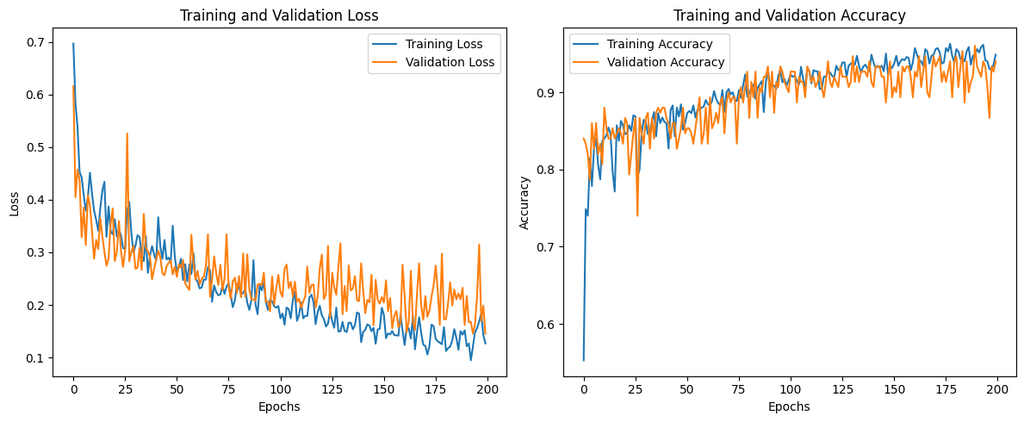

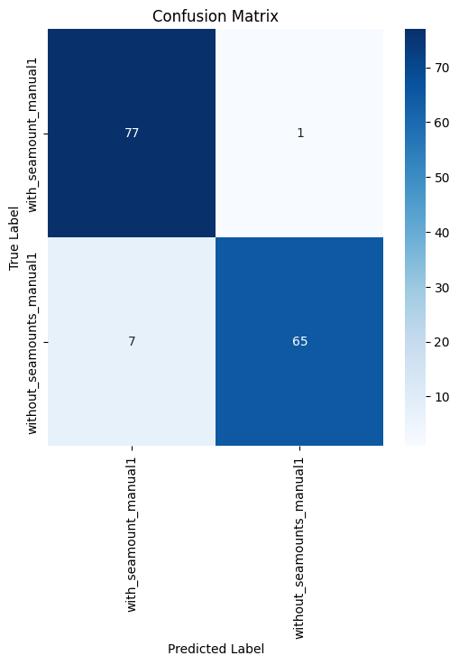

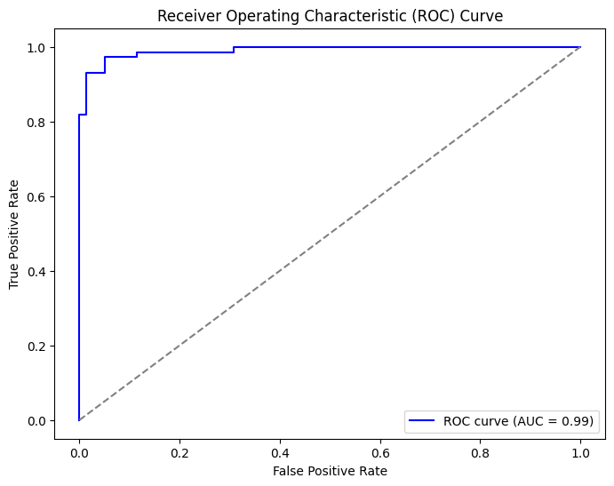

```
Classification Report:
                           precision    recall  f1-score   support

    with_seamount_manual1       0.92      0.99      0.95        78
without_seamounts_manual1       0.98      0.90      0.94        72

                 accuracy                           0.95       150
                macro avg       0.95      0.94      0.95       150
             weighted avg       0.95      0.95      0.95       150

Precision: 0.98
Recall: 0.90
F1 Score: 0.94
```

```python
from sklearn.metrics import confusion_matrix, classification_report, precision_score, recall_score, f1_score, roc_curve, auc
import seaborn as sns
import matplotlib.pyplot as plt
import numpy as np
import tensorflow as tf

# Plotting the training/validation loss and accuracy
plt.figure(figsize=(12, 5))

# Loss plot
plt.subplot(1, 2, 1)
plt.plot(history.history['loss'], label='Training Loss')
plt.plot(history.history['val_loss'], label='Validation Loss')
plt.title('Training and Validation Loss')
plt.xlabel('Epochs')
plt.ylabel('Loss')
plt.legend()

# Accuracy plot
plt.subplot(1, 2, 2)
plt.plot(history.history['accuracy'], label='Training Accuracy')
plt.plot(history.history['val_accuracy'], label='Validation Accuracy')
plt.title('Training and Validation Accuracy')
plt.xlabel('Epochs')
plt.ylabel('Accuracy')
plt.legend()

plt.tight_layout()
plt.show()

# Compute confusion matrix
y_pred = (model.predict(X_test) > 0.5).astype("int32")
cm = confusion_matrix(y_test, y_pred)

# Plot confusion matrix
plt.figure(figsize=(6, 6))
sns.heatmap(cm, annot=True, fmt='d', cmap='Blues', xticklabels=categories, yticklabels=categories)
plt.title('Confusion Matrix')
plt.xlabel('Predicted Label')
plt.ylabel('True Label')
plt.show()

# Compute ROC curve and AUC
fpr, tpr, thresholds = roc_curve(y_test, model.predict(X_test).flatten())
roc_auc = auc(fpr, tpr)

# Plot ROC curve
plt.figure(figsize=(8, 6))
plt.plot(fpr, tpr, color='blue', label=f'ROC curve (AUC = {roc_auc:.2f})')
plt.plot([0, 1], [0, 1], color='gray', linestyle='--')
plt.title('Receiver Operating Characteristic (ROC) Curve')
plt.xlabel('False Positive Rate')
plt.ylabel('True Positive Rate')
plt.legend(loc='lower right')
plt.show()

# Classification report
y_pred = (model.predict(X_test) > 0.5).astype("int32").flatten()
print("Classification Report:")
print(classification_report(y_test, y_pred, target_names=categories))

# Precision, Recall, F1-Score
precision = precision_score(y_test, y_pred)
recall = recall_score(y_test, y_pred)
f1 = f1_score(y_test, y_pred)

print(f"Precision: {precision:.2f}")
print(f"Recall: {recall:.2f}")
print(f"F1 Score: {f1:.2f}")
```

## Show some details about the non-matches

```python
import matplotlib.pyplot as plt
import cv2
import math

# Get the indices of false positives and false negatives
false_positives = []
false_negatives = []

# Loop through the test set to find false positives and false negatives
for i in range(len(y_test)):
    if y_pred[i] == 1 and y_test[i] == 0:  # Predicted 'with_seamounts', but true label is 'without_seamounts' (False Positive)
        false_positives.append(i)
    elif y_pred[i] == 0 and y_test[i] == 1:  # Predicted 'without_seamounts', but true label is 'with_seamounts' (False Negative)
        false_negatives.append(i)


# Display all False Positive images in a grid of 4 columns
num_images = len(false_positives)
columns = 4
rows = math.ceil(num_images / columns)

print(f"Found {num_images} False Positive images - Displaying all")

plt.figure(figsize=(columns * 3, rows * 3))  # Adjust figure size for better visualization

for i, index in enumerate(false_positives):
    image = X_test[index] * 255.0  # Rescale back to original pixel values
    image = image.astype(np.uint8)

    plt.subplot(rows, columns, i + 1)  # Add subplot at the corresponding position
    plt.imshow(cv2.cvtColor(image, cv2.COLOR_BGR2RGB))
    plt.axis('off')  # Remove axes for a cleaner look

plt.tight_layout()  # Adjust layout to avoid overlapping
plt.show()

# Display all False Negative images in a grid of 4 columns
num_images = len(false_negatives)
columns = 4
rows = math.ceil(num_images / columns)

print(f"Found {num_images} False Negative images - Displaying all")

plt.figure(figsize=(columns * 3, rows * 3))  # Adjust figure size for better visualization

for i, index in enumerate(false_negatives):
    image = X_test[index] * 255.0  # Rescale back to original pixel values
    image = image.astype(np.uint8)

    plt.subplot(rows, columns, i + 1)  # Add subplot at the corresponding position
    plt.imshow(cv2.cvtColor(image, cv2.COLOR_BGR2RGB))
    plt.axis('off')  # Remove axes for a cleaner look

plt.tight_layout()  # Adjust layout to avoid overlapping
plt.show()
```

[output not shown]

## Comparative Analysis

To compare the performance of our CNN model with a baseline model, we looked at accuracy and F1 score. Based on prior experience, we expect the CNN model to outperform simpler models in image classification tasks.

In this instance:

- Baseline Model: The best achieved an accuracy around 85%, with lower precision and recall.
- CNN Model: Our CNN model achieved an accuracy of approximately 94-95% and an F1 score of 0.94, which indicates its strong performance in distinguishing between the two classes.